# Function to estimate phenology as a multi-modal Gaussian curve

## Gaussian curve

The parameter $a_1$ determines the maximum height of the curve. The parameter $a_2$ determines the location of the peak. The parameter $a_3$ determines how wide (larger value of $a_3$) or skinny (smaller $a_3$) the curve is.

Let’s make a funciton for this curve and plot it

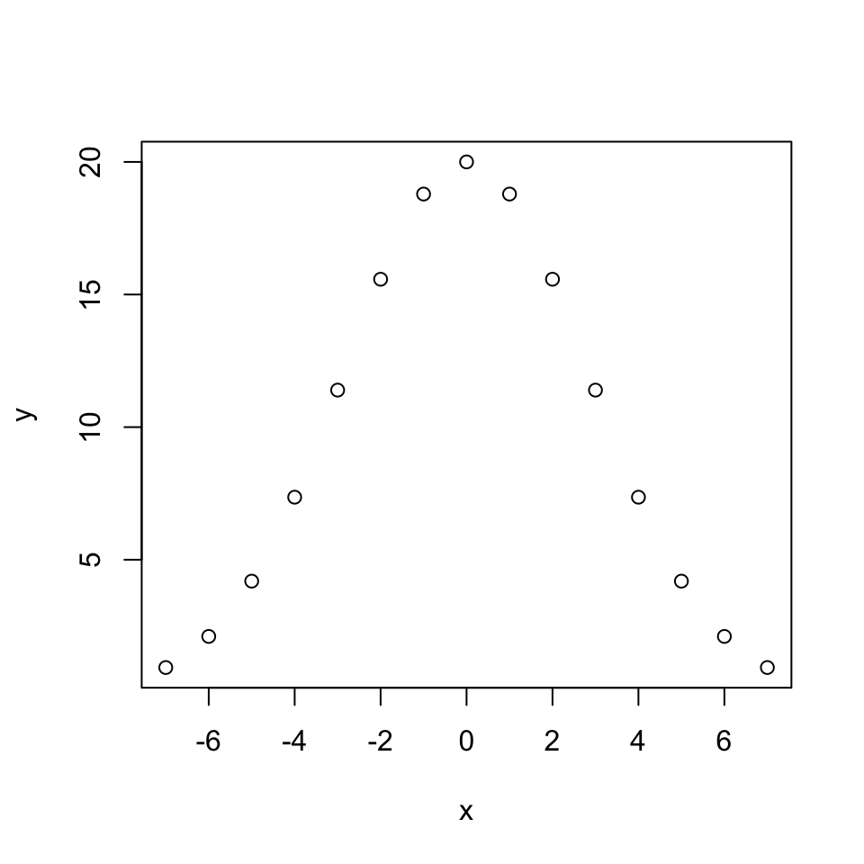

```r
gaus <- function(x, a1, a2, a3) {
    a1 * exp(-(x - a2)^2 / (2 * a3)^2)
}

x <- -7:7
y <- gaus(x, 20, 0, 2)
plot(x, y)
```

Now let’s make a bi-modal Gaussian curve. This is simply a funciton of two Gaussian curves added together, each with it’s own set of parameters, say $a_1, a_2, a_3$ for the first curve, and $b_1, b_2, b_3$ for the second

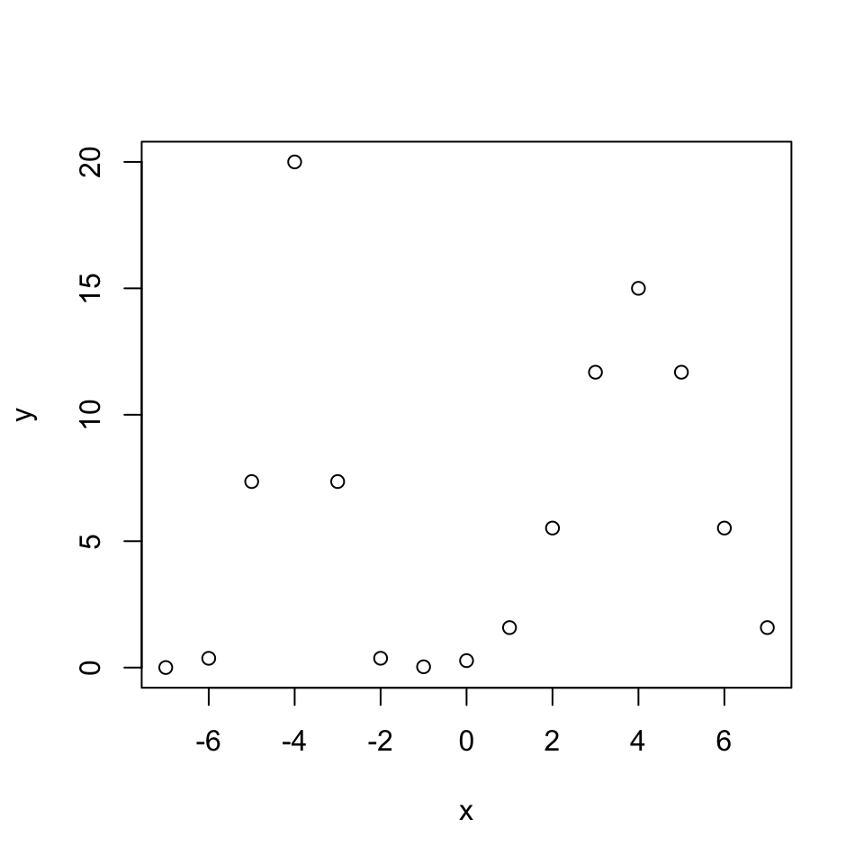

```r
gaus2 <- function(x, a1, a2, a3, b1, b2, b3) {
    a1 * exp(-(x - a2)^2 / (2 * a3)^2) + b1 * exp(-(x - b2)^2 / (2 * b3)^2)
}

x <- -7:7
y <- gaus2(x, 20, -4, 0.5, 15, 4, 1)
plot(x, y)
```

## Bi-modal Gaussian data with noise

Our data will not be smooth like that, instead there will be noise. We can make a first attempt of modeling that noise with a Poisson distribution. This means that for every `x` value, the `y` response will actual be a random number drawn from a Poisson distribution whose mean value comes from the bi-model Gaussian curve. We can simulate data following that idea with an approach like this:

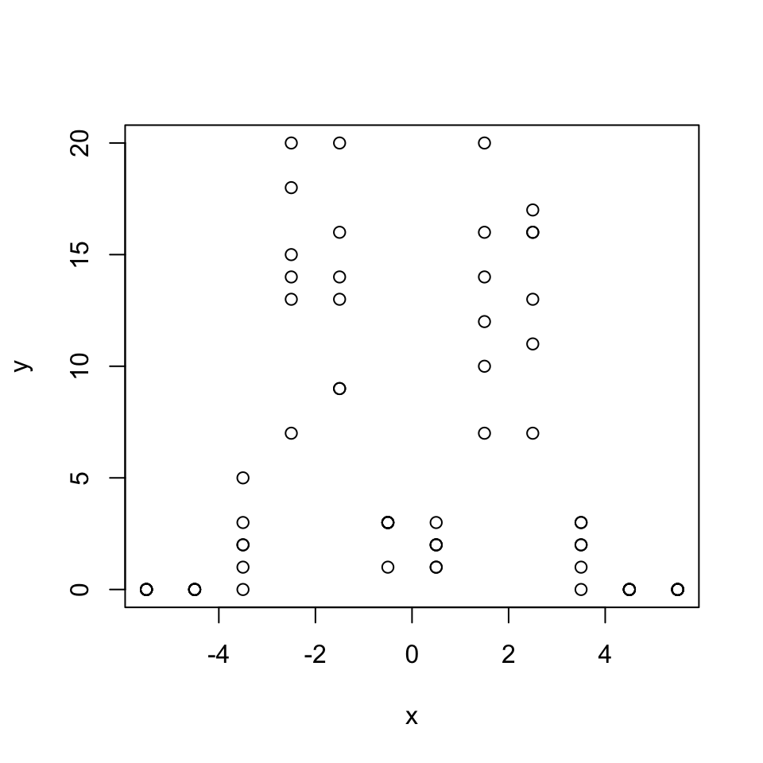

```r
# create realistic calendar sampling times, centered on mid-June
x <- rep((1:12) - 6.5, each = 6)

# for convenience, make a vector of our parameters a1, a2, a3, b1, b2, b3
p <- c(20, -2, 0.5, 20, 2, 0.5)

# now make the mean values for the y variable
ymean <- gaus2(x, p[1], p[2], p[3], p[4], p[5], p[6])

# finally, simulate real data
y <- rpois(length(ymean), ymean)

plot(x, y)
```

## Fitting the curve to real data with noise

To fit the bi-model curve to these kind of real data, we need to define a log likelihood function and maximize it. We will actually make a *negative* log likelihood function and *minimize* it, but those tasks are equivalent, computers just prefer to minimize things. We’ll be using the function `optim` to do that minimization (or *optimization*).

The model we’ve been building toward assumes there is a bi-model Gaussian curve with a potential early season peak and late season peak. The resulting data are assumed to come from a Poisson distribution. Taking that info together, we can make a negative log likelihood function that looks something like this:

```r
gaus2LogLik <- function(p, x, y) {
    a1 <- p[1]
    a2 <- p[2]
    a3 <- p[3]
    b1 <- p[4]
    b2 <- p[5]
    b3 <- p[6]

    mu <- gaus2(x, a1, a2, a3, b1, b2, b3)

    return(-sum(dpois(y, mu, log = TRUE)))
}
```

A couple things to note about this function: we pass it three arguments: `p` is one vector containing all the parameter values (`a1`, `a2`, `a3`, `b1`, `b2`, `b3`) because that’s how `optim` wants it to be; the vector `x` of dates samples were taken; and the vector `y` with the counts for one species.

In this function first we split up our vector `p` into the necessary parameters `a1`, `a2`, `a3`, `b1`, `b2`, `b3`, we then create a vector of mean values (`mu`) and then pass that to the Poisson distribution function `dpois`. What we return is the negative sum of the log values of the Poisson distribution function.

That’s it! That’s the negative log likelihood function.

But before using it, we need to do a few things. The optimization will have a hard time with the fact that in real life all the parameters `a1`, `a2`, `a3`, `b1`, `b2`, `b3` need to be positive, but the optimizer will naively try negative values. We can force it to only work in the positive domain by using the `exp` function like this:

```r
gaus2LogLik <- function(p, x, y) {
    p <- exp(p)

    a1 <- p[1]
    a2 <- p[2]
    a3 <- p[3]
    b1 <- p[4]
    b2 <- p[5]
    b3 <- p[6]

    mu <- gaus2(x, a1, a2, a3, b1, b2, b3)

    return(-sum(dpois(y, mu, log = TRUE)))
}
```

That’s very close to what we need, but the optimizer will have a hard time with one last thing: right now, it doesn’t know that we want it to force an early season peak and a late season peak. But we can make it do that. That’s why we centered the `x` values at mid June, i.e. `6.5` (this could be modified to whatever makes sense, e.g. `6.75`). Assuming we’ve done that kind of centering, we can force the first peak to be before “mid season” by forcing it to always be negative, like this:

```r
gaus2LogLik <- function(p, x, y) {
    p <- exp(p)

    a1 <- p[1]
    a2 <- -p[2]
    a3 <- p[3]
    b1 <- p[4]
    b2 <- p[5]
    b3 <- p[6]

    mu <- gaus2(x, a1, a2, a3, b1, b2, b3)

    return(-sum(dpois(y, mu, log = TRUE)))
}
```

Now we’ve got it. Let’s test out this function with our simulated data from before:

```r
# remember, we saved that vector of parameters
p
```

```
## [1] 20.0 -2.0  0.5 20.0  2.0  0.5
```

```r
# but our new log likelihood function has that funny business with exponentials and
# negatives, so let's make a new p to use with the log likelihood (ll) function
pll <- p
pll[2] <- -pll[2]
pll <- log(pll)
pll
```

```
## [1]  2.9957323  0.6931472 -0.6931472  2.9957323  0.6931472 -0.6931472
```

```r
# and remember the data vectors `x` and `y` exist (and `x` is centered at 6.5)
x
```

```
##  [1] -5.5 -5.5 -5.5 -5.5 -5.5 -5.5 -4.5 -4.5 -4.5 -4.5 -4.5 -4.5 -3.5 -3.5 -3.5
## [16] -3.5 -3.5 -3.5 -2.5 -2.5 -2.5 -2.5 -2.5 -2.5 -1.5 -1.5 -1.5 -1.5 -1.5 -1.5
## [31] -0.5 -0.5 -0.5 -0.5 -0.5 -0.5  0.5  0.5  0.5  0.5  0.5  0.5  1.5  1.5  1.5
## [46]  1.5  1.5  1.5  2.5  2.5  2.5  2.5  2.5  2.5  3.5  3.5  3.5  3.5  3.5  3.5
## [61]  4.5  4.5  4.5  4.5  4.5  4.5  5.5  5.5  5.5  5.5  5.5  5.5
```

```r
y
```

```
##  [1]  0  0  0  0  0  0  0  0  0  0  0  0  1  2  2  5  0  3 15 20 18 13  7 14 20
## [26] 14  9  9 13 16  3  1  3  3  3  3  2  1  2  3  1  2 20  7 16 12 14 10  7 13
## [51] 17 16 11 16  3  3  1  0  2  2  0  0  0  0  0  0  0  0  0  0  0  0
```

```r
# so what is the log likelihood at for the parameter values p
gaus2LogLik(pll, x, y)
```

```
## [1] 109.2298
```

```r
# compare that to something with different parameter values
pllWrong <- pll
pllWrong[c(1, 3, 5)] <- 1
pllWrong
```

```
## [1]  1.0000000  0.6931472  1.0000000  2.9957323  1.0000000 -0.6931472
```

```r
gaus2LogLik(pllWrong, x, y)
```

```
## [1] 346.8008
```

The vector of parameters `pllWrong` is “wrong” in the sense that those were not the parameter values used to simulate the data `y`. So if everything is working right, the negative log likelihood should be **bigger** for the wrong values, and it is.

Now let’s use the function `optim` to minimize the negative log likelihood function for the simulated data. This is exactly what we’ll do for real data too! One thing to note, we have to pass `optim` a vector of initial guesses for the parameter values, we’ll start by using `pll`.

```r
optim(pll, gaus2LogLik, x = x, y = y, method = 'BFGS', hessian = TRUE)
```

```
## $par
## [1]  2.8690351  0.6875462 -0.6420507  2.8389005  0.6947929 -0.6986680
##
## $value
## [1] 105.6727
##
## $counts
## function gradient
##       41       10
##
## $convergence
## [1] 0
##
## $message
## NULL
##
## $hessian
##             [,1]        [,2]       [,3]        [,4]        [,5]       [,6]
## [1,] 196.6145303    4.521797 192.210702   0.5859093   -4.367861   4.285754
## [2,]   4.5217970 1372.844715  43.376532  -4.5279962   31.787884 -29.210655
## [3,] 192.2107020   43.376532 536.910944   5.1435508  -34.383910  29.784326
## [4,]   0.5859093   -4.527996   5.143551 180.2136717    4.373291 176.920722
## [5,]  -4.3678610   31.787884 -34.383910   4.3732906 1435.800804  36.270678
## [6,]   4.2857540  -29.210655  29.784326 176.9207217   36.270678 496.746463
```

Note really quick how we call this function: first we pass the initial guess `pll`, then the function we optimizing `gaus2LogLik`, and then we also have to tell `optim` the values of the `x` and `y` parameters. Finally, we tell optim to use the `BFGS` optimization method, and we tell it to keep the `hessian` (more on that later).

The function `optim` returns a lot of information, all in one list object. The the important things to note are: the element called `$par` gives the maximum likelihood estimates, `$value` gives the optimal negative log likelihood, and `$convergence` tells us if the optimization was successful: a value of `0` is success, any other value is not, you can learn more about the other values in the help doc `?optim`. Excitingly, the model estimates in `$par` are very close to the parameter values (`pll`) that we used to simulate the data. That tells us our estimation procedure is working. We should also check that if we supply `optim` with a different initial guess, that it still converges on this correct answer. So let’s try using `pllWrong` as our initial guess:

```r
optim(pllWrong, gaus2LogLik, x = x, y = y, method = 'BFGS', hessian = TRUE)
```

```
## $par
## [1]  2.8690351  0.6875461 -0.6420508  2.8389007  0.6947929 -0.6986679
##
## $value
## [1] 105.6727
##
## $counts
## function gradient
##       83       22
##
## $convergence
## [1] 0
##
## $message
## NULL
##
## $hessian
##             [,1]        [,2]       [,3]        [,4]        [,5]       [,6]
## [1,] 196.6145005    4.521795 192.210676   0.5859093   -4.367861   4.285757
## [2,]   4.5217951 1372.844742  43.376632  -4.5279944   31.787873 -29.210659
## [3,] 192.2106760   43.376632 536.911003   5.1435471  -34.383884  29.784315
## [4,]   0.5859093   -4.527994   5.143547 180.2137438    4.373291 176.920790
## [5,]  -4.3678614   31.787873 -34.383884   4.3732909 1435.800283  36.270659
## [6,]   4.2857566  -29.210659  29.784315 176.9207900   36.270659 496.746388
```

It gets the same answer so that’s great!

Keeping in mind that these estimates are in log units, let’s make a little convenience function to put them back into linear units:

```r
getParams <- function(p) {
    p <- exp(p)
    p[2] <- -p[2]

    return(p)
}

mod <- optim(pllWrong, gaus2LogLik, x = x, y = y, method = 'BFGS', hessian = TRUE)
getParams(mod$par)
```

```
## [1] 17.6200077 -1.9888292  0.5262122 17.0969610  2.0032941  0.4972473
```

Lastly, a word on the Hessian. This is a matrix of partial derivatives of the likelihood function. It can be used to estimate the standard errors and confidence intervals of each parameter. We won’t go into that now, but keep it in mind if we want to incorporate that later. I wrote a custom package a while back to do that kind of thing (the package is called *socorro*, named after the city, and because it’s a package of helper functions). I’ll put the code here for the sake of completeness. Before running this code, make sure you install the package *devtools*.

```r
library(devtools)
# check if socorro has already been installed
socorroCheck <- require(socorro)
# if it hasn't been installed, install it now
if(!socorroCheck) {
    install_github('ajrominger/socorro')
}

library(socorro)

# parameter confidence intervals
modCI <- wald(mod$par, mod$hessian, alpha = 0.05, marginal = TRUE)
modCI
```

```
##            2.5%      97.5%
## [1,]  2.6955003  3.0425698
## [2,]  0.6344951  0.7405971
## [3,] -0.7474914 -0.5366101
## [4,]  2.6577398  3.0200616
## [5,]  0.6429329  0.7466529
## [6,] -0.8081760 -0.5891597
```

Remember, these are in the funny units we use in the optimization. We can convert them to regular units, again using our convenience function `getParams`

```r
cbind(getParams(modCI[, 1]), getParams(modCI[, 2]))
```

```
##            [,1]       [,2]
## [1,] 14.8129280 20.9590348
## [2,] -1.8860696 -2.0971875
## [3,]  0.4735530  0.5847271
## [4,] 14.2640132 20.4925550
## [5,]  1.9020512  2.1099261
## [6,]  0.4456702  0.5547933
```